# Segmenting the Neighborhoods in Oslo

## Outline:

- Background and problem
- Data description
- Methodology
  1. Collecting the neighborhood and population data
  2. Adding neighborhood area data
  3. Adding data of average housing price
  4. Adding coordinates
  5. Exploratory data analysis on the population, area, housing price, and geography
  6. Adding venue data and EDA on the venues
  7. Clustering Neighborhoods in Oslo
- Results - Predicting where you will live in Oslo
- Discussion
- Conclusion

## Background and problem

Oslo is the fastest-growing capital city in all of Europe. It has around 680,000 friendly people, a strong economy, and great connectivity to the wonderful nature. Oslo is clearly undergoing great change these years and more than 40,000 move into the city each year, according to the Oslo Kommune. Such mobility is expected to continue in the coming years.

Finding a right place to live is non-trivial, especially for those who have never been to Oslo before. People have various preferences on the neighborhoods they want to live in. It would be very helpful if we are able to **segment and characterize the neighborhoods in Oslo and provide some clue of where to live for potential new comers** based on the similarity between the neighborhoods they are currently living in (or they like) with the neighborhoods in Oslo. Popular housing portals in Norway like Finn.no can think about to provide such service to their potential new users.

## Data description

To tackle the above problem, I will need neighborhood data, coordinates of the neighborhoods, and data of venues (e.g. cafe, restaurant) in each neighborhood of Oslo.

The neighborhood data consists of names, average housing prices, area sizes and populations of the neighborhoods. This data is made public by the Oslo Kommune. The coordinates of the neighborhoods can be easily found from Google Maps via its API. The venue data consists of names, addresses, types, etc. of popular venues in each neighborhood. Such data can be obtained from Foursquare by using the Foursquare API.

These pieces of data will be combined and used to segment and characterize neighborhoods in Oslo. The k-means clustering algorithm will be employed to perform this task. Finally, I will predict where you want to live in Oslo if you are from the neighborhood of Chelsea, London!

```python
# Standard library
import sys
import json
import time

# Third party
import folium
import googlemaps
import matplotlib as mpl
import matplotlib.pyplot as plt
import numpy as np
import requests
import pandas as pd
from pandas.io.json import json_normalize
import seaborn as sns
from selenium import webdriver
from selenium.common.exceptions import TimeoutException, StaleElementReferenceException
from sklearn.cluster import KMeans
from sklearn.preprocessing import StandardScaler, MinMaxScaler
from tqdm import tqdm
from wordcloud import WordCloud

# Local application/library
```

```python
%matplotlib inline
```

## Methodology

- Data collection
- Data cleaning
- Exploratory data analysis (EDA)
- Feature selection and transformation
- Segmenting neighborhoods in Oslo using k-means clustering

### Collecting the neighborhood and population data

The website of Oslo Kommune, where we get neighborhood data from, is very interactive. To get the table of the population data, one click of the table button is required. So it's not possible to crawl the data using the Requests and BuiltfulSoup libraries which enable us to crawl data from static webpages. Instead, I use Selenium which gets data by mimicking human web browsing behavior.

```python
url_oslo_kommune = r'https://bydelsfakta.oslo.kommune.no/'
```

```python
# open the website of Oslo Kommune
options = webdriver.ChromeOptions()
browser_path = r'E:\Downloads\chromedriver_win32\chromedriver'
browser = webdriver.Chrome(browser_path, options=options)
browser.get(url_oslo_kommune)
```

I need to first get the list of bydel and their specific webpages (I keep the Norwegian word 'Bydel' in the codes and the report instead of its English counterpart 'Borough' since it's shorter).

```python
bydel_urls = {}
attempts, attempted = 3, 0
while True:
    bydels_list = browser.find_elements_by_class_name('navigation-link__label')
    for bydel in bydels_list:
        bydel_name = bydel.text
        bydel_url = bydel.get_attribute('href')
        bydel_urls[bydel_name] = bydel_url
    attempted += 1
    if len(bydel_urls) != 0 | attempted == attempts:
        break

assert len(bydel_urls) != 0, f"Tried {attempts} times, but didn't get the links of the bydels."
for k, v in bydel_urls.items():
    print(k, v)
```

```
Bydel Gamle Oslo https://bydelsfakta.oslo.kommune.no/bydel/gamleoslo
Bydel Grünerløkka https://bydelsfakta.oslo.kommune.no/bydel/grunerlokka
Bydel Sagene https://bydelsfakta.oslo.kommune.no/bydel/sagene
Bydel St. Hanshaugen https://bydelsfakta.oslo.kommune.no/bydel/sthanshaugen
Bydel Frogner https://bydelsfakta.oslo.kommune.no/bydel/frogner
Bydel Ullern https://bydelsfakta.oslo.kommune.no/bydel/ullern
Bydel Vestre Aker https://bydelsfakta.oslo.kommune.no/bydel/vestreaker
Bydel Nordre Aker https://bydelsfakta.oslo.kommune.no/bydel/nordreaker
Bydel Bjerke https://bydelsfakta.oslo.kommune.no/bydel/bjerke
Bydel Grorud https://bydelsfakta.oslo.kommune.no/bydel/grorud
Bydel Stovner https://bydelsfakta.oslo.kommune.no/bydel/stovner
Bydel Alna https://bydelsfakta.oslo.kommune.no/bydel/alna
Bydel Østensjø https://bydelsfakta.oslo.kommune.no/bydel/ostensjo
Bydel Nordstrand https://bydelsfakta.oslo.kommune.no/bydel/nordstrand
Bydel Søndre Nordstrand https://bydelsfakta.oslo.kommune.no/bydel/sondrenordstrand
```

Once the webpages of all the bydels are found, I will iterate through them and find the neighborhoods in each bydel and their population data. It takes a bit time to open these webpages and get data from them, so a progress bar is implemented to show the current progress.

```python
results_bydels = []
progress_bar = tqdm(bydel_urls)

# get data for each bydel
for bydel in progress_bar:
    progress_bar.set_description(f'Getting data of {bydel} ...')
    result_bydel = []
    # open bydel webpage and find the data table by clicking the table button
    browser.get(bydel_urls[bydel]+'/befolkningsutvikling')
    browser.find_element_by_xpath("//button[@aria-label='Tabell']").click()
    # try 3 time maximum if having StaleElementReferenceException
    attempts, attempted = 3, 0
    while True:
        try:
            while True:
                table = browser.find_element_by_tag_name('tbody').find_elements_by_tag_name('tr')
                if len(table) != 0:
                    break
            for row in table:
                nei_name = row.find_element_by_tag_name('th').text
                # change the number in code below to change year
                nei_pop = row.find_elements_by_tag_name('td')[-1].text
                result_bydel.append([bydel, nei_name, nei_pop])
        except StaleElementReferenceException:
            attempted += 1
            if attempted == attempts:
                print(f'--- Already tried {attempted} times ---')
                raise
            else:
                result_bydel = []
        else:
            results_bydels += result_bydel
            break
```

```
Getting data of Bydel Søndre Nordstrand ...: 100%|█| 15/15 [00:47<00:00,  2.80s/it]
```

```python
df = pd.DataFrame(results_bydels, columns=['Bydel', 'Neighborhood', 'Population'])
```

### Cleaning the population data

```python
df.sample(5)
```

|  | Bydel | Neighborhood | Population |
| --- | --- | --- | --- |
| 66 | Bydel Nordre Aker | Tåsen | 7 672 |
| 10 | Bydel Gamle Oslo | Oslo i alt | 681 071 |
| 51 | Bydel Ullern | Oslo i alt | 681 071 |
| 14 | Bydel Grünerløkka | Rodeløkka | 9 555 |
| 106 | Bydel Østensjø | Skullerud | 7 385 |

Some rows in the data are not about population of a neighborhood but rather about that of a bydel or the whole city. These rows are not useful for this project and thus removed.

```python
df = df[(df.Neighborhood!=df.Bydel) & (df.Neighborhood!='Oslo i alt')].reset_index(drop=True)
```

```python
# check if there is any duplicate
df.duplicated().sum()
```

```
0
```

Change the data type of the Population column from object/string to integer.

```python
df['Population'] = df['Population'].apply(lambda x: ''.join(x.split())).astype(int)
```

Remove the 'Bydel' prefix from the Bydel column, since it's easy to know what they are from the column name.

```python
df['Bydel'] = df['Bydel'].apply(lambda x: ' '.join(x.split()[1:]))
```

```python
df.sample(5)
```

|  | Bydel | Neighborhood | Population |
| --- | --- | --- | --- |
| 21 | Sagene | Torshov | 10616 |
| 94 | Søndre Nordstrand | Mortensrud | 5204 |
| 31 | Frogner | Majorstuen syd | 8984 |
| 23 | St. Hanshaugen | Bislett | 9500 |
| 78 | Østensjø | Manglerud | 10894 |

Let's see how many bydels and neighborhoods are there in Oslo.

```python
print('There are {} bydels and {} neighborhoods in Oslo.'.format(
    len(df['Bydel'].unique()), len(df['Neighborhood'].unique())))
```

```
There are 15 bydels and 96 neighborhoods in Oslo.
```

Note: Officially, Oslo city has 98 neighborhoods or 15 bydels in addition to two special parts to be more precise. The two neighborhoods excluded in this data are Sentrum and Marka. Sentrum is literally the very center of Oslo while Marka is the large forest area surrounding Oslo. Both of them are not administrative unit. People living at Sentrum receive administrative services at St. Hanshaugen and people living at Marka receive administrative services from the nearest bydels.

```python
df[['Bydel', 'Neighborhood']].groupby('Bydel').count().rename(
    columns={'Neighborhood': 'Number of Neighborhood'}).sort_values(
    'Number of Neighborhood').transpose()
```

| Bydel | Bjerke | Grorud | Sagene | St. Hanshaugen | Ullern | Nordstrand | Stovner | Søndre Nordstrand | Østensjø | Alna | Vestre Aker | Frogner | Grünerløkka | Nordre Aker | Gamle Oslo |
| --- | --- | --- | --- | --- | --- | --- | --- | --- | --- | --- | --- | --- | --- | --- | --- |
| Number of Neighborhood | 5 | 5 | 5 | 5 | 5 | 6 | 6 | 6 | 6 | 7 | 7 | 8 | 8 | 8 | 9 |

We can see that Gamle Oslo tops the list with 9 neighborhoods. (The population will be analyzed in the next part together with neighborhood size and housing price and visualized on a map.)

### Adding neighborhood area data

The data of neighborhood sizes can be read into Pandas Dataframe directly from **statistikkbanken.oslo.kommune.no**, or it can be downloaded to local machine from the link and then read into a Dataframe for analysis.

```python
url_neib = r'http://statistikkbanken.oslo.kommune.no/webview/velocity?headers=Arealforml&Geografisubset=301%2C30101+-+30116%2C3010102+-+3011506%2C3011601&stubs=Geografi&measure=common&Arealformlslice=0&virtualslice=Dekar_value&layers=r&layers=virtual&study=http%3A%2F%2F192.168.101.44%3A80%2Fobj%2FfStudy%2FNPS-arealformaal-delbydel&mode=cube&Geografislice=301&virtualsubset=Dekar_value&v=2&rsubset=2017&submode=table&measuretype=4&cube=http%3A%2F%2Fstatistikkbanken.oslo.kommune.no%3A80%2Fobj%2FfCube%2FNPS-arealformaal-delbydel_C1&rslice=2017&Arealformlsubset=0%2C1+-+6&top=yes&executespreadsheet=true'
```

```python
df_area = pd.read_excel(url_neib, skiprows=[0, 1, 2, 3, 4, 5, 6, 8],
                        header=0, usecols=['Arealformål', 'Areal i alt'])
```

```python
# df_area = pd.read_excel('area_oslo_2017.xls', skiprows=[0, 1, 2, 3, 4, 5, 6, 8],
#                         header=0, usecols=['Arealformål', 'Areal i alt'])
```

```python
df_area.sample(6)
```

|  | Arealformål | Areal i alt |
| --- | --- | --- |
| 86 | Delbydel Lindeberg | 1018.2 |
| 72 | Delbydel Rødtvet | 684.3 |
| 14 | Delbydel Dælenenga | 188.2 |
| 52 | Delbydel Slemdal | 2477.8 |
| 98 | Bydel Nordstrand | 15932.6 |
| 43 | Delbydel Lilleaker | 1313.2 |

Some rows in the area data are not about area of a neighborhood but rather about that of a bydel or the whole city. These rows are not useful for this project and thus removed.

```python
df_area = df_area[df_area.Arealformål.apply(
    lambda x: x.startswith('Delbydel'))].reset_index(drop=True)
```

```python
df_area = df_area.rename(columns={'Arealformål':'Neighborhood', 'Areal i alt':'Area'})
```

```python
# remove the 'Delbydel' prefix
df_area['Neighborhood'] = df_area['Neighborhood'].apply(lambda x: ' '.join(x.split()[1:]))
```

```python
# change the Area to km2
df_area['Area'] = df_area['Area'].astype(float)/1000
```

```python
df_area.head()
```

|  | Neighborhood | Area |
| --- | --- | --- |
| 0 | Grønland | 0.3628 |
| 1 | Enerhaugen | 0.3854 |
| 2 | Nedre Tøyen | 0.1972 |
| 3 | Kampen | 0.2642 |
| 4 | Vålerenga | 0.4530 |

### Merging the neighborhood population data and the area data

```python
df_area.info()
```

```
<class 'pandas.core.frame.DataFrame'>
RangeIndex: 96 entries, 0 to 95
Data columns (total 2 columns):
Neighborhood    96 non-null object
Area            96 non-null float64
dtypes: float64(1), object(1)
memory usage: 1.6+ KB
```

We can see that the area data also has 96 neighborhoods. It looks like the neighborhoods in both data are the same. Just to confirm:

```python
set(df['Neighborhood']).symmetric_difference(set(df_area['Neighborhood']))
```

```
set()
```

The difference between the neighborhoods in the two data is an empty set, which means they are the same. Now it's perfectly safe to merge the two pieces of data.

```python
df = pd.merge(df, df_area, how='left', on='Neighborhood')
```

```python
df.sample(6)
```

|  | Bydel | Neighborhood | Population | Area |
| --- | --- | --- | --- | --- |
| 76 | Alna | Tveita | 5521 | 1.7399 |
| 90 | Søndre Nordstrand | Holmlia Syd | 5831 | 1.6476 |
| 53 | Nordre Aker | Nordberg | 9149 | 2.5255 |
| 51 | Nordre Aker | Korsvoll | 5320 | 1.3856 |
| 82 | Østensjø | Skullerud | 7385 | 1.5450 |
| 32 | Frogner | Homansbyen | 10257 | 0.4409 |

People might think it's ok to live with a lot of people in a large neighborhood, but it could be too crowed if living with a lot of people in a small neighborhood. So it's reasonable to create a feature about the population density of each neighborhood.

```python
df['Density'] = df['Population']/df['Area']
```

The following are the five densest neighborhoods in Oslo:

```python
df.sort_values('Density', ascending=False).head()
```

|  | Bydel | Neighborhood | Population | Area | Density |
| --- | --- | --- | --- | --- | --- |
| 2 | Gamle Oslo | Nedre Tøyen | 5254 | 0.1972 | 26643.002028 |
| 0 | Gamle Oslo | Grønland | 9626 | 0.3628 | 26532.524807 |
| 31 | Frogner | Majorstuen syd | 8984 | 0.3457 | 25987.850738 |
| 12 | Grünerløkka | Rodeløkka | 9555 | 0.4002 | 23875.562219 |
| 11 | Grünerløkka | Dælenenga | 4468 | 0.1882 | 23740.701382 |

The following are the five most sparse neighborhoods in Oslo:

```python
df.sort_values('Density').head()
```

|  | Bydel | Neighborhood | Population | Area | Density |
| --- | --- | --- | --- | --- | --- |
| 6 | Gamle Oslo | Bispevika | 2585 | 1.9466 | 1327.956437 |
| 59 | Bjerke | Ulven | 3752 | 2.3641 | 1587.073305 |
| 95 | Søndre Nordstrand | Bjørndal | 9075 | 5.5536 | 1634.075194 |
| 86 | Nordstrand | Bekkelaget | 9777 | 5.6017 | 1745.363015 |
| 27 | Frogner | Bygdøy | 3766 | 1.5845 | 2376.775008 |

### Adding data of average housing price

The data of average square meter price for purchasing a dwelling of the neighborhoods in Oslo can be found at **statistikkbanken.oslo.kommune.no**. Read the data into Pandas Dataframe.

```python
url_housing = r'http://statistikkbanken.oslo.kommune.no/webview/velocity?headers=r&Geografisubset=30100%2C30101+-+30117%2C301010101+-+301161601%2C301171701&stubs=Geografi&measure=common&virtualslice=Gjennomsnittligkvadratmeterpris_value&layers=Boligtype&layers=virtual&study=http%3A%2F%2F192.168.101.44%3A80%2Fobj%2FfStudy%2FNPS-omsatteboliger-kvadratmeterpris&Boligtypesubset=1&mode=cube&Geografislice=30100&virtualsubset=Gjennomsnittligkvadratmeterpris_value&v=2&rsubset=2004+-+2018&Boligtypeslice=1&measuretype=4&rslice=2018&cube=http%3A%2F%2F192.168.101.44%3A80%2Fobj%2FfCube%2FNPS-omsatteboliger-kvadratmeterpris_C1&top=yes&executespreadsheet=true'
```

```python
df_housing = pd.read_excel(url_housing, skiprows=[0, 1, 2, 3, 4, 5, 6, 8],
                           header=0, usecols=['År', '2018'])
```

```python
# df_housing = pd.read_excel('oslo_housing.xls', skiprows=[0, 1, 2, 3, 4, 5, 6, 8],
#                            header=0, usecols=['År', '2018'])
```

```python
df_housing.head()
```

|  | År | 2018 |
| --- | --- | --- |
| 0 | Oslo i alt | 69532 |
| 1 | Bydel Gamle Oslo | 74605 |
| 2 | Delbydel Grønland | 73069 |
| 3 | Delbydel Enerhaugen | 72798 |
| 4 | Delbydel Nedre Tøyen | 74062 |

### Cleaning the housing data

```python
df_housing = df_housing.rename(columns={'År':'Neighborhood', '2018':'Housing'})
```

Some rows in the housing data are not about housing price of a neighborhood but rather about that of a bydel or the whole city. These rows are not useful for this project and thus removed.

```python
df_housing = df_housing[df_housing['Neighborhood'].apply(lambda x: x.startswith('Delbydel'))]
```

```python
# remove 'Delbydel' prefix
df_housing['Neighborhood'] = df_housing['Neighborhood'].apply(lambda x: ' '.join(x.split()[1:]))
```

Convert the Housing column from object to int type since the values are numbers:

```python
def str2int(s):
    """Convert number in string s format to int. Assign NaN value if ValueError raised."""
    try:
        number = int(s)
    except ValueError:
        number = np.nan
    return number
```

```python
df_housing['Housing'] = df_housing['Housing'].apply(str2int)
```

```python
df_housing.info()
```

```
<class 'pandas.core.frame.DataFrame'>
Int64Index: 100 entries, 2 to 115
Data columns (total 2 columns):
Neighborhood    100 non-null object
Housing         96 non-null float64
dtypes: float64(1), object(1)
memory usage: 2.3+ KB
```

We can see there are 4 NaN in the Housing column. They are

```python
df_housing[df_housing['Housing'].isnull()]
```

|  | Neighborhood | Housing |
| --- | --- | --- |
| 7 | Lodalen | NaN |
| 10 | Helsfyr | NaN |
| 20 | Hasle-Løren | NaN |
| 70 | Økern | NaN |

People do use these neighborhood names these days, at least Helsfyr and Økern are heard lots of times. In fact, the neighborhoods in Oslo were revised in 2017, according to the **[Oslo Kommune](https://www.oslo.kommune.no/politikk-og-administrasjon/statistikk/geografiske-inndelinger/)**. Specifically,

- Lodalen was divided into Kværnerbyen and Bispevika.
- Helsfyr became Ensjø and Etterstad.
- Hasle-Løren were seperated to Hasle and Løren.
- Økern became Refstad and Ulven.

Let's see if the new neighborhoods (i.e. Kvaernerbyen, Bispevika, Ensjø, Etterstad, Hasle, Løren, Refstad and Ulven) are in the data or not.

```python
{'Kværnerbyen', 'Bispevika', 'Ensjø', 'Etterstad', 'Hasle', 'Løren', 'Refstad', 'Ulven'
}.issubset(set(df_housing['Neighborhood'].unique()))
```

```
True
```

So the old neighborhoods can be removed from the housing data.

```python
df_housing = df_housing[df_housing['Housing'].notnull()]
```

```python
df_housing.info()
```

```
<class 'pandas.core.frame.DataFrame'>
Int64Index: 96 entries, 2 to 115
Data columns (total 2 columns):
Neighborhood    96 non-null object
Housing         96 non-null float64
dtypes: float64(1), object(1)
memory usage: 2.2+ KB
```

### Merging the population/area data and the housing data

```python
set(df['Neighborhood']).symmetric_difference(set(df_housing['Neighborhood']))
```

```
set()
```

The above result shows the neighborhoods in the two data are the same, so it's ready to merge.

```python
df = pd.merge(df, df_housing, how='left', on='Neighborhood')
```

```python
df.sample(6)
```

|  | Bydel | Neighborhood | Population | Area | Density | Housing |
| --- | --- | --- | --- | --- | --- | --- |
| 32 | Frogner | Homansbyen | 10257 | 0.4409 | 23263.778635 | 85989.0 |
| 46 | Vestre Aker | Vinderen | 5183 | 1.3960 | 3712.750716 | 79967.0 |
| 31 | Frogner | Majorstuen syd | 8984 | 0.3457 | 25987.850738 | 86144.0 |
| 92 | Søndre Nordstrand | Prinsdal | 5697 | 1.1650 | 4890.128755 | 40084.0 |
| 11 | Grünerløkka | Dælenenga | 4468 | 0.1882 | 23740.701382 | 77992.0 |
| 9 | Grünerløkka | Grünerløkka vest | 8397 | 0.4742 | 17707.718262 | 82025.0 |

### Adding coordinates

It's very convenient to obtain coordinates from Google Maps by using its Python library. All you need is a Google Maps API key and a few lines of code.

```python
# the key is private and removed after running all the codes
gmaps = googlemaps.Client(key='***')
```

```python
# get coordinates
oslo = 'Oslo, Norway'
coor = []

for idx, row in df.iterrows():
    where = row.Neighborhood + ', ' + oslo
    geo_result = gmaps.geocode(where)
    lat = geo_result[0]['geometry']['location']['lat']
    long = geo_result[0]['geometry']['location']['lng']
    coor.append((lat, long))

assert len(coor) != 0, "Didn't get the coordinates from Google Maps."
```

Merge the population/area/housing data and the coordinates.

```python
df = pd.concat([df, pd.DataFrame(coor, columns=['Latitude', 'Longitude'])], axis=1)
```

```python
df.sample(6)
```

|  | Bydel | Neighborhood | Population | Area | Density | Housing | Latitude | Longitude |
| --- | --- | --- | --- | --- | --- | --- | --- | --- |
| 64 | Grorud | Romsås | 6891 | 1.3961 | 4935.892844 | 40934.0 | 59.966433 | 10.898105 |
| 0 | Gamle Oslo | Grønland | 9626 | 0.3628 | 26532.524807 | 73069.0 | 59.912178 | 10.762815 |
| 77 | Alna | Teisen | 5810 | 1.6184 | 3589.965398 | 55777.0 | 59.913452 | 10.817264 |
| 36 | Ullern | Lilleaker | 5130 | 1.3132 | 3906.487968 | 72108.0 | 59.919936 | 10.634088 |
| 62 | Grorud | Nordtvet | 5379 | 1.3859 | 3881.232412 | 49143.0 | 59.950733 | 10.872951 |
| 15 | Grünerløkka | Løren | 8596 | 0.9819 | 8754.455647 | 74868.0 | 59.930997 | 10.799287 |

Google Maps usually gets the correct coordinates of places in Norway. However, it can go wrong if searching with a rare name. Let's see how.

First check if there is any duplicate in the coordinates.

```python
df[df[['Latitude', 'Longitude']].duplicated(keep=False)]
```

|  | Bydel | Neighborhood | Population | Area | Density | Housing | Latitude | Longitude |
| --- | --- | --- | --- | --- | --- | --- | --- | --- |
| 9 | Grünerløkka | Grünerløkka vest | 8397 | 0.4742 | 17707.718262 | 82025.0 | 59.926129 | 10.775740 |
| 10 | Grünerløkka | Grünerløkka øst | 5370 | 0.2539 | 21150.059078 | 81541.0 | 59.926129 | 10.775740 |
| 30 | Frogner | Majorstuen nord | 5218 | 0.4126 | 12646.631120 | 88601.0 | 59.926774 | 10.716167 |
| 31 | Frogner | Majorstuen syd | 8984 | 0.3457 | 25987.850738 | 86144.0 | 59.926774 | 10.716167 |
| 90 | Søndre Nordstrand | Holmlia Syd | 5831 | 1.6476 | 3539.087157 | 39335.0 | 59.835423 | 10.789374 |
| 91 | Søndre Nordstrand | Holmlia Nord | 5995 | 1.6564 | 3619.294856 | 43145.0 | 59.835423 | 10.789374 |

Here we can see that Google Maps cannot distinguish Grünerløkka vest (west in Norwegian) and Grünerløkka øst (east in Norwegian). So, it's reasonable to check other neighborhoods with unusual names. Technically, they are mostly the names with more than two words.

```python
df[df['Neighborhood'].apply(lambda x: len(x.split())>1)]
```

|  | Bydel | Neighborhood | Population | Area | Density | Housing | Latitude | Longitude |
| --- | --- | --- | --- | --- | --- | --- | --- | --- |
| 2 | Gamle Oslo | Nedre Tøyen | 5254 | 0.1972 | 26643.002028 | 74062.0 | 59.920441 | 10.754513 |
| 9 | Grünerløkka | Grünerløkka vest | 8397 | 0.4742 | 17707.718262 | 82025.0 | 59.926129 | 10.775740 |
| 10 | Grünerløkka | Grünerløkka øst | 5370 | 0.2539 | 21150.059078 | 81541.0 | 59.926129 | 10.775740 |
| 30 | Frogner | Majorstuen nord | 5218 | 0.4126 | 12646.631120 | 88601.0 | 59.926774 | 10.716167 |
| 31 | Frogner | Majorstuen syd | 8984 | 0.3457 | 25987.850738 | 86144.0 | 59.926774 | 10.716167 |
| 54 | Nordre Aker | Ullevål hageby | 6847 | 1.9216 | 3563.176520 | 91580.0 | 59.943538 | 10.733166 |
| 90 | Søndre Nordstrand | Holmlia Syd | 5831 | 1.6476 | 3539.087157 | 39335.0 | 59.835423 | 10.789374 |
| 91 | Søndre Nordstrand | Holmlia Nord | 5995 | 1.6564 | 3619.294856 | 43145.0 | 59.835423 | 10.789374 |

More are found. It's very difficult to tell whether the coordinates are correct or not just looking at the numbers. So, it's time to show a map using the Folium library.

First, let's take a look at all the neighborhoods in Oslo and inspect the suspects later!

```python
# get coordinates of Oslo
geo_result_oslo = gmaps.geocode(oslo)
lat_oslo = geo_result_oslo[0]['geometry']['location']['lat']
long_oslo = geo_result_oslo[0]['geometry']['location']['lng']
```

```python
# create a map of Oslo
map_oslo = folium.Map(location=[lat_oslo, long_oslo], zoom_start=11)
# add markers of neighborhoods in Oslo
for index, row in df.iterrows():
    folium.CircleMarker(
    location=[row.Latitude, row.Longitude],
    radius=5,
    popup=row.Neighborhood,
    color=None,
    fill=True,
    fill_color='#3186cc',
    fill_opacity=1.0).add_to(map_oslo)
# add center of Oslo
folium.CircleMarker(
    location=[lat_oslo, long_oslo],
    radius=5,
    popup='Sentrum',
    color=None,
    fill=True,
    fill_color='red',
    fill_opacity=0.8).add_to(map_oslo)

map_oslo
```

[interactive chart not shown]

Oslo is well surrounded by forests, lakes and fjord. There are well-built facilities for people to explore around. In summer, people go hiking a lot in the forest, stop by a lake and then swim or take a sunbath. In winter, the forest becomes a ski maze!

**Inspecting the suspects:**

```python
map_sus = folium.Map(location=[lat_oslo, long_oslo], zoom_start=10)

for index, row in df[df['Neighborhood'].apply(lambda x: len(x.split())>1)].iterrows():
    folium.CircleMarker(
    location=[row.Latitude, row.Longitude],
    radius=6,
    popup=row.Neighborhood,
    color=None,
    fill=True,
    fill_color='#3186cc',
    fill_opacity=1.0).add_to(map_sus)

map_sus
```

[interactive chart not shown]

After a bit interaction with the map above and checking with Google Maps, I found that only Ullevål hageby has correct coordinates in the eight suspects. Nedre Tøyen is slightly away from its correct position. Grünerløkka vest/Grünerløkka øst, Majorstuen Nord/Majorstuen syd and Holmlia Syd/Holmlia Nord are overlapped, respectively. Their coordinates are changed to what are found on Google Maps.

```python
df.at[2, 'Latitude'], df.at[2, 'Longitude'] = 59.914917, 10.767262
df.at[9, 'Latitude'], df.at[9, 'Longitude'] = 59.923663, 10.756469
df.at[10, 'Latitude'], df.at[10, 'Longitude'] = 59.923736, 10.760156
df.at[30, 'Latitude'], df.at[30, 'Longitude'] = 59.930944, 10.713439
df.at[31, 'Latitude'], df.at[31, 'Longitude'] = 59.927545, 10.717623
df.at[90, 'Latitude'], df.at[90, 'Longitude'] = 59.827662, 10.795633
df.at[91, 'Latitude'], df.at[91, 'Longitude'] = 59.835494, 10.783908
```

Check on the map whether they are corrected.

```python
map_sus_r = folium.Map(location=[lat_oslo, long_oslo], zoom_start=10)

for index, row in df[df['Neighborhood'].apply(lambda x: len(x.split())>1)].iterrows():
    folium.CircleMarker(
    location=[row.Latitude, row.Longitude],
    radius=6,
    popup=row.Neighborhood,
    color=None,
    fill=True,
    fill_color='#3186cc',
    fill_opacity=1.0).add_to(map_sus_r)

map_sus_r
```

[interactive chart not shown]

### Exploratory data analysis on the population, area, housing price, and geography

Let's take a look at estimated probability distributions of population, area, density and housing price, and their correlations through pairplots.

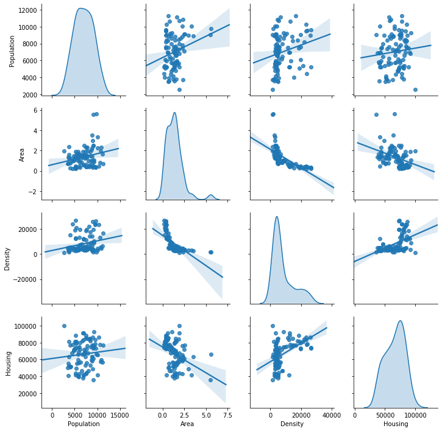

```python
sns.pairplot(df.drop(columns=['Latitude', 'Longitude']), kind="reg", diag_kind="kde")
```

From the diagonal distribution plots, we can observe that:

- The population is quite normally distributed. Not many neighborhoods have too large or small population.
- A few of the neighborhoods are much larger than the rest in size.
- The housing price is a bit left or negative skewed, meaning the majority of the neighborhoods have relatively high housing price.

The pairplot between the area and density shows a negative correlation to some extent that neighborhoods with smaller area sizes tend to be more densely populated.

With the above observations in mind, let's take a look at some visualizations of population, area, and housing price on maps. I use sequential colormaps to plot the values. Darker colors show higher values in the corresponding dimension and vice versa.

```python
def oslo_map(data, feature, colors, city_location):
    """Show on a Folium map a feature of Oslo that range from relatively low values to
    relatively high values. Darker color indicates higher value.

    Keyword arguments:
    data - a Pandas Dataframe
    feature - name of a numeric feature
    colors - a Seaborn palette
    city_location - coordinates of the city
    """
    map_o = folium.Map(location=city_location, zoom_start=10)
    # add markers of neighborhoods in Oslo
    for idx, row in data.sort_values(feature).reset_index().iterrows():
        folium.CircleMarker(
        location=[row.Latitude, row.Longitude],
        radius=5,
        popup=f'{row.Neighborhood}, {row[feature]}',
        color=None,
        fill=True,
        fill_color=mpl.colors.to_hex(colors[idx]),
        fill_opacity=1.0).add_to(map_o)
    return map_o
```

**Population:**

```python
colors_pop = sns.light_palette('red', n_colors=len(df))
map_oslo_pop = oslo_map(df, 'Population', colors_pop, [lat_oslo, long_oslo])
map_oslo_pop
```

[interactive chart not shown]

**Area:**

```python
colors_area = sns.light_palette('purple', n_colors=len(df))
map_oslo_area = oslo_map(df, 'Area', colors_area, [lat_oslo, long_oslo])
map_oslo_area
```

[interactive chart not shown]

It can be seen that neighborhoods in the inner city are relatively small and densely located.

**Population density:**

```python
colors_density = sns.light_palette('blue', n_colors=len(df))
map_oslo_density = oslo_map(df, 'Density', colors_density, [lat_oslo, long_oslo])
map_oslo_density
```

[interactive chart not shown]

It's quite clear that the neighborhoods in the inner city are quite densely populated, compared to those in the outer city. However, Fossum, which is located at the northwestern Oslo, has a density of about 12171/km2.

**Housing price:**

```python
colors_housing = sns.color_palette('Wistia', n_colors=len(df))
map_oslo_housing = oslo_map(df, 'Housing', colors_housing, [lat_oslo, long_oslo])
map_oslo_housing
```

[interactive chart not shown]

It's not difficult to see that the housing prices of the neighborhoods in the inner city are very high. If zooming out a bit, it becomes clear that west of Oslo has higher housing price than east of Oslo in general.

### Adding venue data and EDA on the venues

Foursquare is a location-based social networking platform. Their APP provides personalized recommendations of places to go near a user's current location. Now Foursquare has shifted its attention from its consumer APPs to a growing business-to-business operation. We are able to access their venue data through Foursquare API.

```python
# define Foursquare credentials and version
# the keys are private and removed after running all the codes
CLIENT_ID = '***'
CLIENT_SECRET = '***'
VERSION = '20191127'
```

First, let's explore the venues near Majorstuen syd, one of the most popular neighborhoods. There are the famous Vigland park with nude statues and the magnificent Colosseum cinema.

```python
example = 'Majorstuen syd'  # 'Bjørnerud'
lat_example = df[df.Neighborhood == example]['Latitude'].values[0]
long_example = df[df.Neighborhood == example]['Longitude'].values[0]
print('The coordinates of {} are {}, {}'.format(example, lat_example, long_example))
```

```
The coordinates of Majorstuen syd are 59.927545, 10.717623
```

It's a bit sad that maximum 100 nearby venues can be found for each location with a free Foursquare account. However, 100 is not few for some neighborhoods which you will see later.

```python
# create the GET request URL
LIMIT = 100  # maximum allowed
radius = 2000  # meters
url_example = r'https://api.foursquare.com/v2/venues/explore?client_id={}&client_secret={}&v={}&ll={},{}&radius={}&limit={}'
url_example = url_example.format(
    CLIENT_ID, CLIENT_SECRET, VERSION, lat_example, long_example, radius, LIMIT)
url_example
```

```
'https://api.foursquare.com/v2/venues/explore?client_id=AC3OVNEKEW4QU3YSUTBHHWNAIVLC5EPWTUAFK025AFRG3VZJ&client_secret=GH34VAXIJZCER2E435DLOKD5NEKGDGESU1VRG4ZVRJSEL0Q1&v=20191127&ll=59.927545,10.717623&radius=2000&limit=100'
```

```python
attempts, attempted = 3, 0
while True:
    results_example = requests.get(url_example).json()
    attempted += 1
    condition = ('errorType' not in results_example['meta'])
    if condition | attempted == attempts:
        break

assert condition, f"Tried {attempted} times, but didn't not get venue data."
```

```python
def get_category_type(row):
    """Extract the category of the venue."""
    try:
        categories_list = row['categories']
    except:
        categories_list = row['venue.categories']

    if len(categories_list) == 0:
        return None
    else:
        return categories_list[0]['name']
```

```python
venues = results_example['response']['groups'][0]['items']
# flatten JSON
nearby_venues = json_normalize(venues)
# filter columns
filtered_columns = ['venue.name', 'venue.categories', 'venue.location.lat', 'venue.location.lng']
nearby_venues =nearby_venues.loc[:, filtered_columns]
# filter the category for each row
nearby_venues['venue.categories'] = nearby_venues.apply(get_category_type, axis=1)
# clean columns
nearby_venues.columns = [col.split(".")[-1] for col in nearby_venues.columns]

nearby_venues.head()
```

|  | name | categories | lat | lng |
| --- | --- | --- | --- | --- |
| 0 | Kverneriet | Burger Joint | 59.929214 | 10.714634 |
| 1 | Pust | Café | 59.930431 | 10.714796 |
| 2 | Cru | Scandinavian Restaurant | 59.927293 | 10.722774 |
| 3 | Jacobs Majorstuen | Supermarket | 59.929529 | 10.711440 |
| 4 | HiYoga | Yoga Studio | 59.927498 | 10.720616 |

```python
print('{} venues around {} were returned by Foursquare.'.format(nearby_venues.shape[0], example))
```

```
100 venues around Majorstuen syd were returned by Foursquare.
```

```python
nearby_venues.groupby('categories')[['name']].count().rename(
    columns={'name': 'Number'}).sort_values(['Number'], ascending=False).transpose()
```

| categories | Bakery | Pizza Place | Scandinavian Restaurant | Park | Café | Coffee Shop | Indian Restaurant | Wine Shop | Steakhouse | Supermarket | ... | French Restaurant | Art Museum | Cocktail Bar | Deli / Bodega | Japanese Restaurant | Mexican Restaurant | Convenience Store | Multiplex | Palace | Yoga Studio |
| --- | --- | --- | --- | --- | --- | --- | --- | --- | --- | --- | --- | --- | --- | --- | --- | --- | --- | --- | --- | --- | --- |
| Number | 8 | 6 | 5 | 5 | 4 | 4 | 3 | 3 | 2 | 2 | ... | 1 | 1 | 1 | 1 | 1 | 1 | 1 | 1 | 1 | 1 |

1 rows × 56 columns

Most of these venues are about food or place people can hang out! No wonder it's a popular neighborhood.

Now let's get the venues near all the neighborhoods in Oslo.

```python
def getNearbyVenues(names, latitudes, longitudes, radius=2000):
    """Get all the nearby venues for all the neighborhoods from Foursquare. Return a Pandas
    Dataframe containing the folowing features:
    ['Neighborhood', 'Neighborhood Latitude', 'Neighborhood Longitude', 'Venue',
    'Venue Latitude', 'Venue Longitude', 'Venue Category'].
    """
    venues_list = []

    for name, lat, lng in zip(names, latitudes, longitudes):
        # create the API request URL
        url = r'https://api.foursquare.com/v2/venues/explore?&client_id={}&client_secret={}&v={}&ll={},{}&radius={}&limit={}'
        url = url.format(CLIENT_ID, CLIENT_SECRET, VERSION, lat, lng, radius, LIMIT)
        # make the GET request
        results = requests.get(url).json()["response"]['groups'][0]['items']
        # return only relevant information for each nearby venue
        venues_list.append([(
            name, lat, lng,
            v['venue']['name'],
            v['venue']['location']['lat'],
            v['venue']['location']['lng'],
            v['venue']['categories'][0]['name']) for v in results])

    nearby_venues = pd.DataFrame([item for venue_list in venues_list for item in venue_list])
    nearby_venues.columns = ['Neighborhood',
                  'Neighborhood Latitude',
                  'Neighborhood Longitude',
                  'Venue',
                  'Venue Latitude',
                  'Venue Longitude',
                  'Venue Category']
    return nearby_venues
```

```python
# get all the venues around the neighborhoods in Oslo
venues_oslo = getNearbyVenues(names=df['Neighborhood'], latitudes=df['Latitude'],
                              longitudes=df['Longitude'], radius=2000)
```

```python
# venues_oslo = pd.read_csv('oslo_venues_11272019.csv').drop(
#     columns=['Unnamed: 0', 'General Category'])
```

```python
venues_oslo.sample(6)
```

|  | Neighborhood | Neighborhood Latitude | Neighborhood Longitude | Venue | Venue Latitude | Venue Longitude | Venue Category |
| --- | --- | --- | --- | --- | --- | --- | --- |
| 3621 | Montebello-Hoff | 59.935008 | 10.665467 | Røa Senter | 59.947919 | 10.644035 | Shopping Mall |
| 3455 | Ullernåsen | 59.931520 | 10.655893 | Starbucks Skøyen | 59.920722 | 10.682594 | Coffee Shop |
| 4121 | Disen | 59.942881 | 10.794430 | SBIO Kroa | 59.948234 | 10.769835 | Bar |
| 1936 | Bjølsen | 59.940793 | 10.758077 | Xeast | 59.949364 | 10.765525 | Asian Restaurant |
| 2150 | Torshov | 59.933769 | 10.764016 | Mini Sushi | 59.926425 | 10.776312 | Sushi Restaurant |
| 2548 | Fagerborg | 59.931906 | 10.728321 | Jewel of India | 59.915844 | 10.716844 | Indian Restaurant |

Let's see how many venues are found for each neighborhood.

```python
venues_oslo_grouped = venues_oslo.groupby('Neighborhood')[['Venue']].count().rename(
    columns={'Venue': 'Number of venues'})
venues_oslo_grouped.sort_values(['Number of venues']).transpose()
```

| Neighborhood | Bjørndal | Stovner | Romsås | Ellingsrud | Vestli | Holmlia Syd | Holmlia Nord | Ammerud | Grorud | Rommen | ... | Frogner | Grünerløkka vest | Fagerborg | Ensjø | Rodeløkka | Enerhaugen | Dælenenga | Disen | Sinsen | Grünerløkka øst |
| --- | --- | --- | --- | --- | --- | --- | --- | --- | --- | --- | --- | --- | --- | --- | --- | --- | --- | --- | --- | --- | --- |
| Number of venues | 6 | 9 | 11 | 13 | 14 | 15 | 16 | 18 | 18 | 19 | ... | 100 | 100 | 100 | 100 | 100 | 100 | 100 | 100 | 100 | 100 |

1 rows × 96 columns

It's unexpected that only a few venues were found for neighborhoods like Bjørndal, Vestli and Stovner. Perhaps Foursquare is not so popular in Norway and many venues are missing in Foursquare platform. This gives a warning that the machine learning model to be built might not work as expected since the venue data is a bit imbalanced.

How the venues found by Foursquare are distributed in the city?

```python
map_venues = folium.Map(location=[lat_oslo, long_oslo], zoom_start=11)

for index, row in pd.merge(venues_oslo_grouped, df[['Neighborhood', 'Latitude', 'Longitude']],
                           how='left', on='Neighborhood').iterrows():
    folium.CircleMarker(
    location=[row['Latitude'], row['Longitude']],
    radius=row['Number of venues']/10,
    popup='{}, {}'.format(row.Neighborhood, row['Number of venues']),
    color=None,
    fill=True,
    fill_color='blue',
    fill_opacity=0.8).add_to(map_venues)

map_venues
```

[interactive chart not shown]

It's very obvious that neighborhoods in the outer city tend to have very few venues found by Foursquare. Let's see how many venues in total were found by Foursquare.

```python
num_venues = len(venues_oslo)
num_venues_unique = (num_venues
                     - venues_oslo[['Venue', 'Venue Latitude', 'Venue Longitude']].duplicated().sum())
print('{} venues were returned in total, but there are only {} unique venues.'.format(
    num_venues, num_venues_unique))
```

```
5841 venues were returned in total, but there are only 1282 unique venues.
```

The reason is that some neighborhoods are small. It's unavoidable that the near ranges of neighborhoods overlap with a radius of 2000 meters. Even though, it takes time to explore all these venues. I was wondering what are they.

```python
venues_oslo_unique = venues_oslo[
    venues_oslo[['Venue', 'Venue Latitude', 'Venue Longitude']].duplicated() == False]
freq_dict = venues_oslo_unique['Venue Category'].value_counts().to_dict()
```

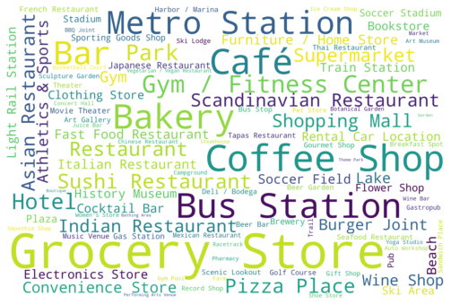

```python
# create and generate a word cloud image
wordcloud = WordCloud(width=3000, height=2000, max_words=100,
                      background_color="white").generate_from_frequencies(freq_dict)
plt.figure(figsize=(10, 6))
plt.imshow(wordcloud, interpolation="bilinear")
plt.axis("off")
plt.show()
```

Grocery store, coffee shop, bakery, bar, gym/fitness center, bus station ... There are too many types of venues and may compromise the performance of the clustering algorithm if they are directly fed into the algorithm. Perhaps it's easier to process them if they can be grouped into several larger categories. For example, Sushi restaurant, Italian restaurant and Indian restaurant are all restaurant.

Actually, Foursquare provides these general categories and their corresponding sub-categories. Unfortunately, they are not included in the collected data. I need to crawl them from the following webpage:

```python
url_4squre = r'https://developer.foursquare.com/docs/resources/categories'
browser.get(url_4squre)
time.sleep(5)
```

```python
attempts, attempted = 10, 0
while True:
    cates = browser.find_elements_by_class_name('categoryItem')
    attempted += 1
    if len(cates) != 0 | attempted == attempts:
        break

assert len(cates) != 0, f"Tried {attempts} times, but didn't get the categories from {url_4squre}"
```

```python
cates_general = ['Arts & Entertainment', 'College & University', 'Food',
                 'Professional & Other Places', 'Nightlife Spot', 'Outdoors & Recreation',
                 'Shop & Service', 'Travel & Transport', 'Residence']
cate_mapping = []

for c in cates:
    cate_name = c.find_element_by_class_name('categoryName').text
    if cate_name in cates_general:
        cate_general = cate_name
    else:
        cate_mapping.append([cate_name, cate_general])
```

```python
venues_oslo = pd.merge(
    venues_oslo,
    pd.DataFrame(cate_mapping, columns=['Venue Category', 'General Category']),
    how='left', on='Venue Category')
```

```python
venues_oslo.info()
```

```
<class 'pandas.core.frame.DataFrame'>
Int64Index: 5841 entries, 0 to 5840
Data columns (total 8 columns):
Neighborhood              5841 non-null object
Neighborhood Latitude     5841 non-null float64
Neighborhood Longitude    5841 non-null float64
Venue                     5841 non-null object
Venue Latitude            5841 non-null float64
Venue Longitude           5841 non-null float64
Venue Category            5841 non-null object
General Category          5834 non-null object
dtypes: float64(4), object(4)
memory usage: 410.7+ KB
```

```python
venues_oslo[venues_oslo['General Category'].isnull()]
```

|  | Neighborhood | Neighborhood Latitude | Neighborhood Longitude | Venue | Venue Latitude | Venue Longitude | Venue Category | General Category |
| --- | --- | --- | --- | --- | --- | --- | --- | --- |
| 326 | Kampen | 59.912926 | 10.779606 | Det Grønne Kjøkken | 59.909938 | 10.777444 | Food | NaN |
| 412 | Vålerenga | 59.907900 | 10.788162 | Det Grønne Kjøkken | 59.909938 | 10.777444 | Food | NaN |
| 513 | Kværnerbyen | 59.904743 | 10.785200 | Det Grønne Kjøkken | 59.909938 | 10.777444 | Food | NaN |
| 727 | Ensjø | 59.914615 | 10.787758 | Det Grønne Kjøkken | 59.909938 | 10.777444 | Food | NaN |
| 817 | Etterstad | 59.909584 | 10.798022 | Det Grønne Kjøkken | 59.909938 | 10.777444 | Food | NaN |
| 4228 | Myrer | 33.682202 | -78.927894 | Red Barn Tavern | 33.694713 | -78.942925 | Food | NaN |
| 5609 | Simensbråten | 59.896900 | 10.789408 | Det Grønne Kjøkken | 59.909938 | 10.777444 | Food | NaN |

```python
venues_oslo['General Category'] = venues_oslo['General Category'].fillna('Food')
```

Now let's see how many venues are there in each general category.

```python
venues_oslo_unique = venues_oslo[
    venues_oslo[['Venue', 'Venue Latitude', 'Venue Longitude']].duplicated() == False]
```

```python
venues_oslo_unique['General Category'].value_counts()
```

```
Food                           415
Shop & Service                 313
Outdoors & Recreation          226
Travel & Transport             159
Nightlife Spot                  84
Arts & Entertainment            81
Professional & Other Places      3
College & University             1
Name: General Category, dtype: int64
```

It shows only one venue in the College & University category. However, there are other universities like BI and OsloMet. Clearly the data provided by Foursquare (or with free account) is not thorough.

```python
browser.quit()
```

So fall, all the data are collected and cleaned. It's time to build machine learning model and cluster the neighborhoods!

### Clustering Neighborhoods in Oslo

#### Feature selection and Data transformation

The features selected for modeling are 'General Category' of venues, population 'Density' and 'Housing' price. I believe they are the features matter the most to people who want to move to Oslo.

```python
onehot = pd.get_dummies(venues_oslo[['General Category']], prefix='', prefix_sep='')
onehot['Neighborhood'] = venues_oslo['Neighborhood']
# move the Neighborhood column to the first column
fixed_columns = [onehot.columns[-1]] + list(onehot.columns[:-1])
onehot = onehot[fixed_columns]
df_clustering = onehot.groupby('Neighborhood').sum().reset_index()
df_clustering = pd.merge(df_clustering, df[['Neighborhood', 'Density', 'Housing']],
                        how='left', on='Neighborhood')
features4clustering = df_clustering.columns
```

```python
df_clustering.head()
```

|  | Neighborhood | Arts & Entertainment | College & University | Food | Nightlife Spot | Outdoors & Recreation | Professional & Other Places | Shop & Service | Travel & Transport | Density | Housing |
| --- | --- | --- | --- | --- | --- | --- | --- | --- | --- | --- | --- |
| 0 | Abildsø | 2 | 0 | 8 | 0 | 14 | 0 | 23 | 7 | 3049.468257 | 52715.0 |
| 1 | Ammerud | 0 | 0 | 6 | 0 | 3 | 0 | 8 | 1 | 5882.534776 | 56047.0 |
| 2 | Bekkelaget | 2 | 0 | 4 | 0 | 9 | 0 | 7 | 4 | 1745.363015 | 65742.0 |
| 3 | Bislett | 8 | 0 | 56 | 11 | 13 | 0 | 8 | 4 | 23387.493845 | 83612.0 |
| 4 | Bispevika | 8 | 0 | 44 | 23 | 7 | 0 | 12 | 6 | 1327.956437 | 100125.0 |

```python
# Standardize the values because the ranges of some features like Density and Housing
# are significantly larger than other features like Food and Nightlife Spot. This will
# impose unbalanced impact on the k-means clustering algorithm.
scaler = StandardScaler()
data_clustering = df_clustering.drop(columns=['Neighborhood'])
scaler = scaler.fit(data_clustering)
data_clustering = scaler.fit_transform(data_clustering)
```

#### Building k-means clustering model

I will be using k-means clustering algorithm to segment the neighborhoods in Oslo based on their similarities. This classic algorithm is relatively simple to implement, and it scales to large data sets, guarantees convergence and adapts to new examples easily.

Before running the k-means, we need to manually specify the desired number of clusters, k. Since there is no clear hint of the best k in the case, I simply try different numbers ranging from 1 to 20 and see what k is good choice based on the elbow method.

The elbow method gives an idea on how to choose a good k based on the total point-to-centroid distance. As k, the number of clusters increases, clusters become smaller and the total distance decreases. We choose the k where the total distance starts to flatten out and forming an elbow, as any larger number gives marginal performance gain.

```python
cost = []
ks = range(1, 20)
for k in ks:
    kmeans = KMeans(n_clusters=k, random_state=0).fit(data_clustering)
    kmeans.labels_
    cost.append(kmeans.inertia_)
```

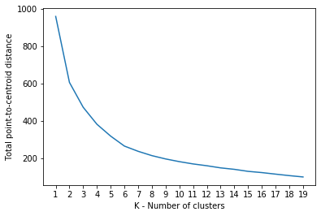

```python
fig = plt.plot(ks, cost)
plt.xticks(ks)
plt.xlabel('K - Number of clusters')
plt.ylabel('Total point-to-centroid distance')
plt.show()
```

The above figure suggests 6, 7 and 8 are good k. So let's take a number in the middle and segment the neighborhoods in Oslo into 7 clusters and plot the result on a map.

```python
kmeans = KMeans(n_clusters=7, random_state=0).fit(data_clustering)
labels = kmeans.labels_
```

```python
labels
```

```
array([1, 5, 5, 4, 4, 0, 5, 5, 6, 5, 2, 4, 5, 4, 0, 0, 0, 5, 6, 6, 1, 1,
       2, 3, 5, 4, 4, 4, 4, 0, 5, 1, 1, 2, 5, 5, 6, 1, 5, 0, 4, 4, 1, 2,
       0, 1, 1, 1, 0, 1, 5, 1, 6, 6, 1, 1, 5, 1, 1, 4, 2, 1, 5, 5, 5, 2,
       4, 5, 5, 1, 5, 0, 2, 1, 0, 6, 5, 6, 3, 4, 5, 1, 0, 1, 1, 2, 1, 1,
       3, 1, 6, 5, 5, 3, 0, 1])
```

```python
df_clustering = pd.merge(
    df_clustering, df[['Neighborhood', 'Latitude', 'Longitude']],
    how='left', on=['Neighborhood'])
df_clustering = pd.concat(
    [df_clustering, pd.Series(labels, name='Cluster').apply(int)], axis=1)
```

```python
colors = ['blue', 'green', 'brown', 'cyan', 'purple', 'orange',
          'red', 'pink', 'gray', 'black']  # 'beige'
df_clustering['Color'] = df_clustering['Cluster'].apply(lambda x: colors[x])
```

```python
map_clusters = folium.Map(location=[lat_oslo, long_oslo], zoom_start=10)

for idx, row in df_clustering.iterrows():
    folium.CircleMarker(
    location=[row.Latitude, row.Longitude],
    popup=row.Neighborhood+' - Cluster '+str(row.Cluster),
    radius=6,
    color=None,
    fill=True,
    fill_color=row.Color,
    fill_opacity=0.7).add_to(map_clusters)

map_clusters
```

[interactive chart not shown]

Do the clusters make any sense? It's obvious that some of the clusters (i.e. those in inner city) do have geographic pattern. But there are more things can characterize the clusters in beside geographic correlation. Let me explain.

```python
df_chara = df_clustering.drop(columns=['Latitude', 'Longitude']).groupby('Cluster').mean()
df_chara_color = df_clustering.drop(
    columns=['Latitude', 'Longitude']).groupby('Cluster')['Color'].agg(pd.Series.mode)
```

```python
df_chara
```

| Cluster | Arts & Entertainment | College & University | Food | Nightlife Spot | Outdoors & Recreation | Professional & Other Places | Shop & Service | Travel & Transport | Density | Housing |
| --- | --- | --- | --- | --- | --- | --- | --- | --- | --- | --- |
| 0 | 5.416667 | 0.0 | 49.083333 | 16.500000 | 18.750000 | 0.083333 | 8.416667 | 0.583333 | 11816.727379 | 76136.000000 |
| 1 | 2.307692 | 0.0 | 9.538462 | 1.115385 | 7.576923 | 0.000000 | 18.576923 | 6.961538 | 4379.887441 | 61594.423077 |
| 2 | 5.250000 | 0.0 | 20.000000 | 2.250000 | 12.875000 | 1.250000 | 17.125000 | 8.000000 | 5708.504696 | 73530.625000 |
| 3 | 4.750000 | 1.0 | 27.250000 | 5.500000 | 13.000000 | 0.250000 | 11.750000 | 6.500000 | 3337.262366 | 78486.500000 |
| 4 | 6.000000 | 0.0 | 48.923077 | 25.230769 | 10.076923 | 0.000000 | 8.153846 | 1.615385 | 18950.385029 | 80368.769231 |
| 5 | 0.750000 | 0.0 | 3.666667 | 0.041667 | 5.250000 | 0.000000 | 7.375000 | 2.625000 | 4686.149703 | 47001.250000 |
| 6 | 10.111111 | 0.0 | 48.666667 | 2.444444 | 15.111111 | 0.000000 | 15.444444 | 4.888889 | 13378.061290 | 86832.666667 |

The table above provides the mean of each feature for each cluster. You can figure out the characteristics of the clusters by studying the numbers. It just takes a while. To help quicker characterize the clusters, I assign three general levels, i.e. High, Medium and Low, to each feature in the above table. See the new table below:

```python
def number2level(X):
    """Convert a number in [0, 1] to three general levels - Low, Medium, High.
    Note that the ranges of the levels are not the same.
    """
    if X >= 3/4:
        level = 'High'
    elif 1/4 <= X <3/4:
        level = 'Medium'
    else:
        level = 'Low'

    return level
```

```python
df_chara_levels = pd.merge(
    df_chara_color,
    df_chara.apply(lambda x: (x-x.min()) / (x.max()-x.min())).applymap(number2level),
    how='left', on='Cluster')

df_chara_levels
```

| Cluster | Color | Arts & Entertainment | College & University | Food | Nightlife Spot | Outdoors & Recreation | Professional & Other Places | Shop & Service | Travel & Transport | Density | Housing |
| --- | --- | --- | --- | --- | --- | --- | --- | --- | --- | --- | --- |
| 0 | blue | Medium | Low | High | Medium | High | Low | Low | Low | Medium | Medium |
| 1 | green | Low | Low | Low | Low | Low | Low | High | High | Low | Medium |
| 2 | brown | Medium | Low | Medium | Low | Medium | High | High | High | Low | Medium |
| 3 | cyan | Medium | High | Medium | Low | Medium | Low | Medium | High | Low | High |
| 4 | purple | Medium | Low | High | High | Medium | Low | Low | Low | High | High |
| 5 | orange | Low | Low | Low | Low | Low | Low | Low | Medium | Low | Low |
| 6 | red | High | Low | High | Low | Medium | Low | Medium | Medium | Medium | High |

## Results - Predicting where you will live in Oslo

We already know which neighborhoods in Oslo are alike. Now it's time to predict which neighborhoods you are going to like in Oslo. Suppose you are currently live at Chelsea, London and you like there.

### Collecting data of Chelsea

Chelsea is an affluent area of South West London, bounded to the south by the River Thames. I choose Chelsea not because it's full of wealth but because one of my favorite football player N'Golo Kanté plays for Chelsea Football Club.

To predict the similarity between any neighborhood and the neighborhoods in Oslo, I need data of this neighborhood that has to have all the features as the data of the neighborhoods in Oslo has.

The population density can be found at **[Wikipedia](https://en.wikipedia.org/wiki/Royal_Borough_of_Kensington_and_Chelsea)**, which gives 13000/km2.

The housing price can be found at **[www.ons.gov.uk](https://www.ons.gov.uk/peoplepopulationandcommunity/housing/articles/housepriceshowmuchdoesonesquaremetrecostinyourarea/2017-10-11)**, which shows that one square meter of floor space – an area about the size of a red phone box – costs almost £19,439 in Kensington and Chelsea.

```python
density_chelsea = 13000  # per km2
housing_chelsea = 228900  # £19439
```

```python
# get coordinates of Chelsea
chelsea = 'Chelsea, London, UK'
geo_result_chelsea = gmaps.geocode(chelsea)
lat_chelsea = geo_result_chelsea[0]['geometry']['location']['lat']
long_chelsea = geo_result_chelsea[0]['geometry']['location']['lng']
print('The coordinates of {} are {}, {}'.format(chelsea, lat_chelsea, long_chelsea))
```

```
The coordinates of Chelsea, London, UK are 51.4869429, -0.170037
```

When getting the venues near Chelsea, I intended to shrink the radius to 1000 meters because Foursquare has more thorough data about venues in Chelsea. Besides, British people do not walk as much as Norwegians.

```python
venues_chelsea = getNearbyVenues([chelsea], [lat_chelsea], [long_chelsea], radius=1000)
```

```python
print('{} venues around Chelsea were returned by Foursquare.'.format(
    venues_chelsea.shape[0]))
```

```
100 venues around Chelsea were returned by Foursquare.
```

```python
venues_chelsea = pd.merge(
    venues_chelsea,
    pd.DataFrame(cate_mapping, columns=['Venue Category', 'General Category']),
    how='left', on='Venue Category')
```

```python
venues_chelsea.sample(5)
```

|  | Neighborhood | Neighborhood Latitude | Neighborhood Longitude | Venue | Venue Latitude | Venue Longitude | Venue Category | General Category |
| --- | --- | --- | --- | --- | --- | --- | --- | --- |
| 11 | Chelsea, London, UK | 51.486943 | -0.170037 | My Old Dutch | 51.486640 | -0.171038 | Creperie | Food |
| 80 | Chelsea, London, UK | 51.486943 | -0.170037 | Oddono's | 51.493609 | -0.176264 | Ice Cream Shop | Food |
| 38 | Chelsea, London, UK | 51.486943 | -0.170037 | Here Organic Food-Supermarket | 51.488016 | -0.169524 | Organic Grocery | Shop & Service |
| 85 | Chelsea, London, UK | 51.486943 | -0.170037 | Macellaio | 51.492663 | -0.177437 | Italian Restaurant | Food |
| 66 | Chelsea, London, UK | 51.486943 | -0.170037 | Aux Merveilleux de Fred | 51.492408 | -0.177589 | Dessert Shop | Food |

### Prediction

Transform Chelsea data as how the data points of the neighborhoods in Oslo were transformed before feeding into k-means clustering.

```python
row_chelsea = pd.get_dummies(
    venues_chelsea[['General Category']], prefix='', prefix_sep='').sum()
```

```python
row_chelsea
```

```
Arts & Entertainment      2
Food                     65
Nightlife Spot            5
Outdoors & Recreation    10
Shop & Service           15
Travel & Transport        3
dtype: int64
```

```python
row_chelsea['Density'] = density_chelsea
row_chelsea['Housing'] = housing_chelsea
row_chelsea['Neighborhood'] = chelsea
row_chelsea['College & University'] = 0
row_chelsea['Professional & Other Places'] = 0
```

```python
row_chelsea = row_chelsea.reindex(index=features4clustering)
```

```python
row_chelsea
```

```
Neighborhood                   Chelsea, London, UK
Arts & Entertainment                             2
College & University                             0
Food                                            65
Nightlife Spot                                   5
Outdoors & Recreation                           10
Professional & Other Places                      0
Shop & Service                                  15
Travel & Transport                               3
Density                                      13000
Housing                                     228900
dtype: object
```

```python
chelsea4clustering = scaler.transform(row_chelsea.drop('Neighborhood').to_numpy().reshape(1, -1))
```

```python
chelsea_in_oslo = kmeans.predict(chelsea4clustering)[0]
chelsea_in_oslo
```

```
6
```

```python
df_clustering[df_clustering['Cluster'] == chelsea_in_oslo].drop(
    columns=['Latitude', 'Longitude'])['Neighborhood'].to_list()
```

```
['Bygdøy',
 'Frogner',
 'Frognerparken',
 'Homansbyen',
 'Majorstuen nord',
 'Majorstuen syd',
 'Skillebekk',
 'Skøyen',
 'Uranienborg']
```

```python
map_pred = folium.Map(location=[lat_oslo, long_oslo], zoom_start=12)

for index, row in df_clustering[df_clustering['Cluster'] == chelsea_in_oslo].iterrows():
    folium.CircleMarker(
    location=[row['Latitude'], row['Longitude']],
    radius=7,
    popup=row['Neighborhood'],
    color=None,
    fill=True,
    fill_color=df_chara_color[chelsea_in_oslo],
    fill_opacity=0.8).add_to(map_pred)

map_pred
```

[interactive chart not shown]

No wonder. They are all to the west of their respective city centers! Or it's because they are all the affluent areas in their respective cities.

## Discussion

From the above prediction, the k-means clustering model seems working reasonably well on segmenting the neighborhoods in Oslo and providing suggestions to new comers. Nevertheless, there are ways to improve its performance. For example, as mentioned earlier in this report, the venue data from Foursquare is not very thorough. If the venue of OsloMet University is included in the venue data, perhaps Homansbyen will be less similar with Chelsea. So more thorough data of the venues can better characterize the neighborhoods. One possible solution is resort to Google Maps for more venues (This project requires to use Foursquare data so I am not going to try in this project).

To make such service more practical, the scope of the data can be extended to the Great Oslo Region, because many people work in Oslo city area and live in cities or towns such as Sandvika and Lillestrøm. However, this will be a much larger and complex project.

The codes for the project are far from production, though they can be ran without error so far. In the case of e.g. adding new features and predicting more examples, the codes need to be always fast, resilient and free of error. This could be a future direction.

## Conclusion

In this project, I have built a recommender that provides suggestions for people who are going to move to Oslo and looking for a general area to live. The recommendation is based on the similarities between the current neighborhood and the neighborhoods in Oslo. To obtain such similarities, I have collected data of the neighborhoods in Oslo from difference websites such as Oslo Kommune and Foursquare. The features of the data include population, area size, coordinates, and nearby venues. After collecting and cleaning the data, I have performed EDA on the features and found some observations such as neighborhoods with smaller area sizes tend to be more densely populated. Through EDA, I have identified a few features for segmenting the neighborhoods in Oslo. K-means clustering algorithm was selected to perform the segmentation task. It has been found that all the neighborhoods can be well segmented into seven clusters. I have provided detailed explanation to justify the clustering result and characterize the clusters. Finally, I have chosen a virtual person currently living at Chelsea, London to test my k-means clustering model, which suggests Chelsea is similar with the neighborhoods in Frogner, Oslo.